# Git Branching: Moving to recommended model

Theory, practice and demo

Ian J Mitchell

Dennis Behm

(Mathieu Dalbin)

## Agenda

- Setting the context
  - Aims and Assumptions
- Fundamentals of the branching strategy
  - Supported workflows
- The pipelines in action - demo time!

## Setting the context

- Devops is foundational to modernization.
- Modernization of Devops is no longer a voyage of exploration.
  - (But plenty people will still try to convince you otherwise!)
- No single tool or approach covers the entire journey to the destination.

We have a [Guide](https://ibm.github.io/z-devops-acceleration-program/docs/ibm-z-devops-solution)… yes, it would be better if it were a map!

## The Guide

[figure not shown]

#### Sneak-peek - new Guide landing page

[figure not shown]

## Today’s topic - Branching Strategy for Mainframe Teams

[figure not shown]

## … don’t just take our word for it

[figure not shown]

[Microsoft Azure Devops Services](https://learn.microsoft.com/en-us/azure/devops/repos/git/git-branching-guidance?view=azure-devops)

# Lifecycle and terminology comparison

## Code storage and developer experience

| Developer Experience | Old | New |
| --- | --- | --- |
| Source Code Storage | PDS Members | UNIX/Linux Filesystem |
| Editing | ISPF | IDEs: IDZ, VSCode |
| Versioning | Package IDs | Git **branches**/commits |

## Processes and Automation:

| Process | Old | New |
| --- | --- | --- |
| Building | JCL | **Automated Pipeline** scripts |
| Approval | Proprietary | Pull Requests |
| Deployment | JCL | IBM Wazi Deploy, IBM Urban Code Deploy |

# Aims and Assumptions

Some aims and assumptions that guide our recommendations…

## No baggage

Well… *[travel light](https://community.ibm.com/community/user/ibmz-and-linuxone/blogs/mathieu-dalbin/2023/11/22/a-no-baggage-approach-to-new-mainframe-development?communityKey=b68f8006-7e86-4043-843f-df16dc7065f9)* perhaps!

- Are we *prescriptive* or just *opinionated*?
  - Aim to be *git-native*!
- We start with a recommendation
  - Confidently
- We question everything
  - **YAGNI** - “you aren’t gonna need it”
- We strive for simplicity
  - For each user’s experience

## Scaling

- The workflow and branching scheme should both scale up and scale down.
  - Small teams with simple and infrequent changes will be able to easily understand, adopt, and have a good experience.
  - Large, busy teams with many concurrent activities will be able to plan, track, and execute with maximum agility using the same fundamental principles.

## Planning

- Planning and design activities as well as code development aim to align to a regular release cadence.
- The cadence of the next planned release is defined by the application team.
- Planning assumptions should aim as much as possible to complete changes quickly, ideally within one release cycle.
  - DevOps/Agile practices to break down larger changes into sets of **smaller, incremental** deliverables that can each be completed within an iteration.

# The Branching Strategy

## Starting Simple

Every change starts in a branch.

```
---
config:
  fontFamily: "IBM Plex Sans"
  gitGraph:
    showCommitLabel: false
---
gitGraph
  commit
  commit
  branch feature/001
  commit
```

- Developers work in the branch to make changes, perform user builds and unit tests.
- A branch holds multiple commits (changes to multiple files).

## Starting Simple

Every change starts in a branch.

```
---
config:
  fontFamily: "IBM Plex Sans"
  gitGraph:
    showCommitLabel: false
---
gitGraph
  commit
  commit
  branch feature/001
  commit
  commit
```

These changes on these branches are

- built,
- tested,
- reviewed and
- approved before merging to `main`.

## Preparing to Merge into `main`

Feature Team/Developers will:

- Build
  - Builds may be done to any commit on any branch
  - Feature branch **must** build cleanly for a Pull Request
- Test
  - To prove quality of the changes in their feature branch

```
---
config:
  fontFamily: "IBM Plex Sans"
  gitGraph:
    showCommitLabel: false
---
gitGraph
  commit
  commit
  branch feature/001
  commit
  commit
  checkout main
  merge feature/001
```

## Merging into `main`

Create a Pull Request (PR) to signal to Team Leaders/Release Controllers to:

- Review
  - Code and Test results
- Approve
  - Safeguard the quality of `main`

```
---
config:
  fontFamily: "IBM Plex Sans"
  gitGraph:
    showCommitLabel: false
---
gitGraph
  commit
  commit
  branch feature/001
  commit
  commit
  checkout main
  merge feature/001
```

`main` and other long-lived branches are *protected* (not everyone can `push` or `merge` to them).

## Before you ask… no, there is no *Production* branch

CI/CD decouples the building and deploying to test environments and production.

We have no branches named `prod` (or `test` or `QA`)

- Those are *environments* to which builds can be deployed
- Such extra branches:
  - are unnecessary
  - cause ambiguity
  - impose merging and building overheads
- Deployment manager is maintaining what is deployed where and provides traceability from developer to production deployment

## Testing a release candidate

Any point in the history of `main` can be declared a *release candidate*.

- Build a *release candidate* package
- Deploy it
- Test it

```
---
config:
  fontFamily: "IBM Plex Sans"
  gitGraph:
    mainBranchOrder: 2
    showCommitLabel: false
---
gitGraph
  commit
  commit
  branch feature/001 order: 3
  commit
  commit
  checkout main
  merge feature/001
  commit tag: "RC1"
  branch maintenance/release1.1
  commit tag: "Build, deploy, test"
```

Tag the commit (point in `main`’s history) with a release name.

## Deploying to production

When…

- all the committed work items for the next planned release are ready to be shipped, and
- all quality gates have passed successfully and the required approvals have been issued by the appropriate reviewers,

the release package can be deployed to production…

## Deploying to production

```
---
config:
  fontFamily: "IBM Plex Sans"
  gitGraph:
    mainBranchOrder: 4
    showCommitLabel: false
---
gitGraph
  commit
  commit
  branch feature/001 order: 4
  commit
  commit
  checkout main
  merge feature/001
  commit tag: "RC1"
  branch maintenance/release2.2-RC1 order: 3
  commit tag: "Build, deploy, test"
  checkout main
  branch feature/002 order: 4
  commit
  checkout main
  merge feature/002
  commit tag: "RC2"
  branch maintenance/release2.2.0-RC2 order: 2
  commit tag: "Build, deploy, test"
  checkout main
  commit tag: "Rel2.2"
  branch maintenance/release2.2.0 order: 1
  commit tag: "Build, deploy, test, release"
```

## Release maintenance branches

A *release maintenance* branch will be used if *hot-fixes* must be developed and delivered.

```
---
config:
  fontFamily: "IBM Plex Sans"
  gitGraph:
    mainBranchOrder: 2
    showCommitLabel: false
---
gitGraph
  commit
  commit tag: "rel2.1.0"
  branch maintenance/rel2.1.x order: 1
  commit
  checkout main
  commit
  branch feature/001 order: 2
  commit
  checkout main
  commit
  branch feature/002 order: 1
  commit
  checkout main
  merge feature/001
  checkout maintenance/rel2.1.x
  branch hotfix/001 order: 0
  commit
  checkout maintenance/rel2.1.x
  merge hotfix/001
  commit tag: "rel2.1.1"
  checkout main
  merge feature/002
```

## Scaling up

Concurrent *feature* branches scale very well, but assume short cycle times.

- Ideally live within a release delivery cycle
- But no big deal if they don’t

*Epic* branches can collect multiple features

- Before going to `main`
- When the delivery is planned beyond the next release

(*Epic* branches are a form of *integration* branch.)

## Integration branches

```
---
config:
  fontFamily: "IBM Plex Sans"
  gitGraph:
    mainBranchOrder: 2
    showCommitLabel: false
---
gitGraph
  commit
  checkout main
  commit
  branch epic/proj001/001 order: 3
  commit
  branch feature/proj001/004 order: 4
  commit
  checkout epic/proj001/001
  branch feature/proj001/005 order: 5
  commit
  checkout feature/proj001/004
  commit
  checkout main
  commit
  branch feature/001 order: 2
  commit
  checkout main
  branch feature/002 order: 1
  commit
  checkout epic/proj001/001
  merge feature/proj001/004
  checkout main
  merge feature/001
  checkout epic/proj001/001
  merge feature/proj001/005
  checkout feature/002
  commit
  checkout main
  merge feature/002
  branch feature/003 order: 2
  commit
  checkout main
  merge feature/003
  commit tag: "rel2.2.0"
  checkout epic/proj001/001
  commit tag: "continue-epic"
```

## Convention over configuration

The principles are more important that the tools and names.

Naming conventions - making purpose obvious:

- `main` : single source of truth. The only long-living branch.
- `release/rel-2.0.1` : explicit versioning numbering to identify releases maintenance branch.
- `epic/47-ai-fraud-detection` : development initiative identified by epic id and description.

## Convention over configuration

Changes are implemented on feature branches:

- `feature/<jira-id|servicenow-id>-new-mortgage-calculation` : references to other planning tools for new features for the next planned release.
- `feature/47-ai-fraud-detection/refactor-mortgage-calculation`: feature implemented for development initiative
- `hotfix/rel-2.0.1/fix-mortgage-calc`: fix implemented for release rel-2.0.1

Names of branches and tags flow through to builds and deployments.

# Workflows supported by the strategy

How do teams work with and benefit from the branch strategy?

## The types of workflows

1. Work and focus on the **next planned release** via the `main` branch. After planning the work items for the next release, the development team is adding changes to the main branch.
2. **Resolution of a production problem** in the currently-released version of the application by leveraging a release maintenance branch that is used for maintenance purposes,
3. **concurrent development activities for significant development initiatives**, which include multiple planned work items for a later delivery (including starting development of a future release) by creating an epic branch from a commit point in the history of main.

*The following narratives complement the structure.*

## Features for the next planned release

**Developer activities:**

1. Take item from backlog
2. Create feature branch
3. Code locally
4. Build with DBB User Build
5. Commit into feature branch, build and test feature functionality
6. Create Pull Request for review and approval

## Features for the next planned release

**Release control activities:**

7. Merge approved branches to `main` and build
8. When planned features have merged, build and tag Release Candidate package
9. Deploy Release Candidate to test environments
10. (*Release candidate can be superceded*)
11. Finalise Release package in Artifactory (or equivalent)
12. Tag commit from step 8 as the production release and deploy

# Simplifying pipeline implementations

## Plan your Pipeline Architecture

- Different pipelines orchestrators are used by customers
- Principle implementations need to safeguard discussed principles and rules

[figure not shown]

## Common needs across all implementations

- Computation of a unique build high-level qualifier
- Set build configuration depending on the lifecycle the user is in
  - Compile with test options
  - Compile with optimize options
- Enforcing a common strategy to store packages in your enterprise binary repository

## Pipeline templates and common backend services

Pipeline templates for the various pipeline orchestrators + common set of services that implement the recommended workflow.

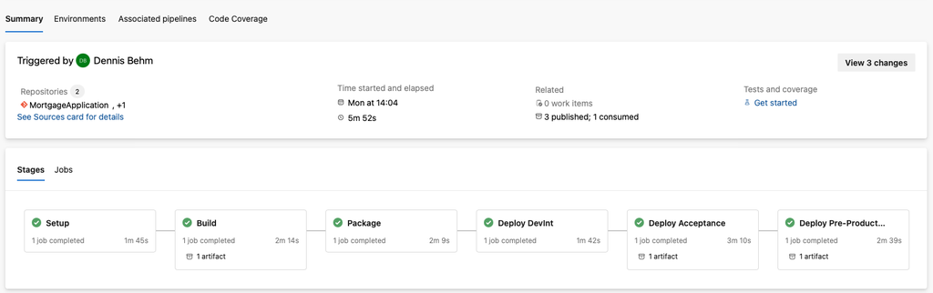

# Collateral

## References

- zDevOps adoption enablement website - [Git branching for mainframe development](https://ibm.github.io/z-devops-acceleration-program/docs/branching/git-branching-model-for-mainframe-dev)
- [A no-baggage approach to new Mainframe development practices](https://www.linkedin.com/posts/mathieu-dalbin-2b219732_a-no-baggage-approach-to-new-mainframe-development-activity-7133752966355791876-e6dS?utm_source=share&utm_medium=member_desktop)
- Pipeline templates - [IBM DBB Community Repository](https://github.com/IBM/dbb/tree/main/Templates)
- Videos
  - [Using the branching model](https://mediacenter.ibm.com/tag?tagid=git%20branching%20model) (4 short videos)
  - [Day in the life of a mainframe developer using Git](https://mediacenter.ibm.com/playlist/details/1_0o0vq1h9/categoryId/189147203)

[figure not shown]

Check out [this presentation](https://ijmitch.github.io/zdevops-git/ukge-2025-branching-and-building.html#/title-slide) in [Github](https://github.com/ijmitch/zdevops-git/)!

# THANK YOU!

Submit your feedback at:

https://conferences.gse.org.uk/2025V/feedback/AG

*(Make sure you are signed into MyGSE)*